# Tutorial: R Markdown

Your name

2024-12-20

### **Learning objectives**

- Become familiar with the R Markdown syntax and code chunk rules
- Understand how to include figures and tables in your Markdown reports
- Create R Markdown files and export them to HTML and Microsoft Word files

### **Why R Markdown?**

All lab assignments will be completed within an R Markdown document.

This file provides an overview of R Markdown. If you’re reading a knitted version of this document (e.g., under the “Jupyter Hub, R, and RStudio - Resources” module in Canvas), the `.Rmd` file that was used to create it was provided to you in Week 2 of class (`Intro_to_RMarkdown.Rmd`).

Note: Some of the below content was borrowed from a tutorial about R Markdown at [Coding Club](https://ourcodingclub.github.io/tutorials/rmarkdown/).

### **The YAML header**

At the top of an R Markdown document, there is a YAML header section enclosed by `---`. By default, it includes a title, author, date and the file type you want to output to. For this class, you will produce HTML (`.html`) and MS Word (`.docx`) documents. The instructors may return the Word document back to you with comments. Make sure to replace “Your name” with your actual name. The “date” will be automatically generated using the `Sys.Date()` function, which returns the current date.

### **Code chunks**

The first code chunk in R Markdown may contain R packages that are needed to run your code. For this file, we use the `here()` and `knitr()` packages.

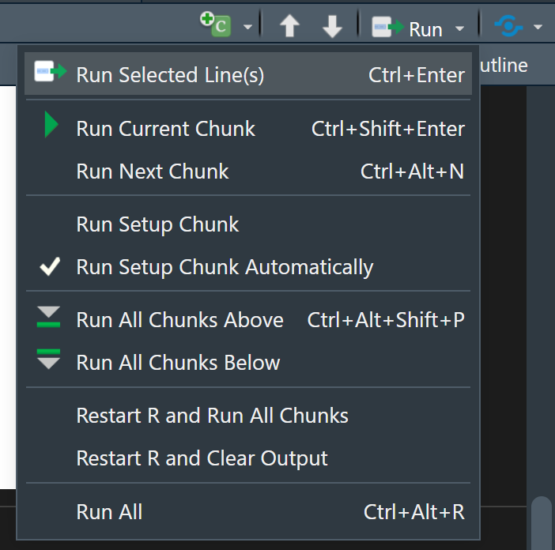

You might want to create an object, but not include both the code and the output in the final `.html` file. To do this you can use, include = FALSE. Be aware though, when making reproducible research it’s often not a good idea to completely hide some part of your analysis.

To insert an external figure, you can use the `include_graphics` function in the `knitr` R package, as shown above in the screenshot of the run options.

There are several options for inserting tables.

One is the `kable()` function from the `knitr` package. Also checkout the `gt()` function in the `gt` package and the `pander()` function in the `pander` package.

```r
kable(pressure)
```

| temperature | pressure |
| --- | --- |
| 0 | 0.0002 |
| 20 | 0.0012 |
| 40 | 0.0060 |
| 60 | 0.0300 |
| 80 | 0.0900 |
| 100 | 0.2700 |
| 120 | 0.7500 |
| 140 | 1.8500 |
| 160 | 4.2000 |
| 180 | 8.8000 |
| 200 | 17.3000 |
| 220 | 32.1000 |
| 240 | 57.0000 |
| 260 | 96.0000 |
| 280 | 157.0000 |
| 300 | 247.0000 |
| 320 | 376.0000 |
| 340 | 558.0000 |
| 360 | 806.0000 |

You can manually create small tables using R Markdown syntax. For example:

| Plant | Temp. | Growth |
| --- | --- | --- |
| A | 20 | 0.65 |
| B | 20 | 0.95 |
| C | 20 | 0.15 |

There are several other code chunk instructions that you could learn about (see **R Markdown Resources** below).

### **Formatting text**

Once you knit your document, the output will display text formatted according to the following simple rules.

*Italic*

Italic

**Bold**

Bold

This is `code` in text

This is code in text

# Header 1

Header 1 (larger font)

## Header 2

Header 2 (smaller font than Header 1)

Note that when a # symbol is placed inside a code chunk it acts as a normal R comment, but when placed in text it controls the header size.

- Unordered list item

Unordered list item

1. Ordered list item

Ordered list item

[Link](https://www.google.com)

Web link

$A = \pi \times r^{2}$

Rendered equation example

The $ symbols tells R markdown to use LaTeX equation syntax.

### **Practice**

To practice this, try writing some formatted text in your `.Rmd` document, add some additional code, and produce an `.html` and `.docx` file using the `Knit` button.

### **R Markdown Resources**

Here are some tutorials and other potentially helpful documents. These same resources are also listed in the “R Markdown Resources” page on Canvas.

Official site  
- [Website for R Markdown](https://rmarkdown.rstudio.com)

Books (online and free)  
- [R Markdown: The Definitive Guide](https://bookdown.org/yihui/rmarkdown)  
- [R Markdown Cookbook](https://bookdown.org/yihui/rmarkdown-cookbook)  
- [R Markdown | R for Data Science](https://r4ds.had.co.nz/r-markdown.html)

Tutorials  
- [Getting started with R Markdown (Coding Club)](https://ourcodingclub.github.io/tutorials/rmarkdown)  
- [R Markdown quick tour (RStudio)](https://rmarkdown.rstudio.com/authoring_quick_tour.html)  
- [Getting started with R Markdown - Guide and Cheatsheet (Dataquest)](https://www.dataquest.io/blog/r-markdown-guide-cheatsheet)  
- [Getting started with R Markdown (Data Carpentry)](https://datacarpentry.org/r-socialsci/06-rmarkdown.html)